How to Data

# How to check the assumptions of a linear model (in R)

See all solutions.

## Task

If you plan to use a linear model to describe some data, it’s important to check if it satisfies the assumptions for linear regression. How can we do that?

## Solution

When performing a linear regression, the following assumptions should be checked.

### 1. We have two or more columns of numerical data of the same length.

The solution below uses an example dataset about car design and fuel consumption from a 1974 Motor Trend magazine. (See how to quickly load some sample data.) We can see that our columns all have the same length.

```r
df <- mtcars
head(df)
```

```
                  mpg  cyl disp hp  drat wt    qsec  vs am gear carb
Mazda RX4         21.0 6   160  110 3.90 2.620 16.46 0  1  4    4
Mazda RX4 Wag     21.0 6   160  110 3.90 2.875 17.02 0  1  4    4
Datsun 710        22.8 4   108   93 3.85 2.320 18.61 1  1  4    1
Hornet 4 Drive    21.4 6   258  110 3.08 3.215 19.44 1  0  3    1
Hornet Sportabout 18.7 8   360  175 3.15 3.440 17.02 0  0  3    2
Valiant           18.1 6   225  105 2.76 3.460 20.22 1  0  3    1
```

### 2. Scatter plots we’ve made suggest a linear relationship.

Scatterplots are covererd in how to create basic plots, but after making the model, we can also examine the residuals.

So let’s make the model. Our predictors will be the number of cylinders and the weight of the car and the response will be miles per gallon. (See also how to fit a linear model to two columns of data.)

```r
model = lm(mpg~ cyl + wt, data=df)
```

We test for linearity with residual plots. We show just one residual plot here; you should make one for each predictor. R’s plot function knows how to create residual plots. (See also how to compute the residuals of a linear model.)

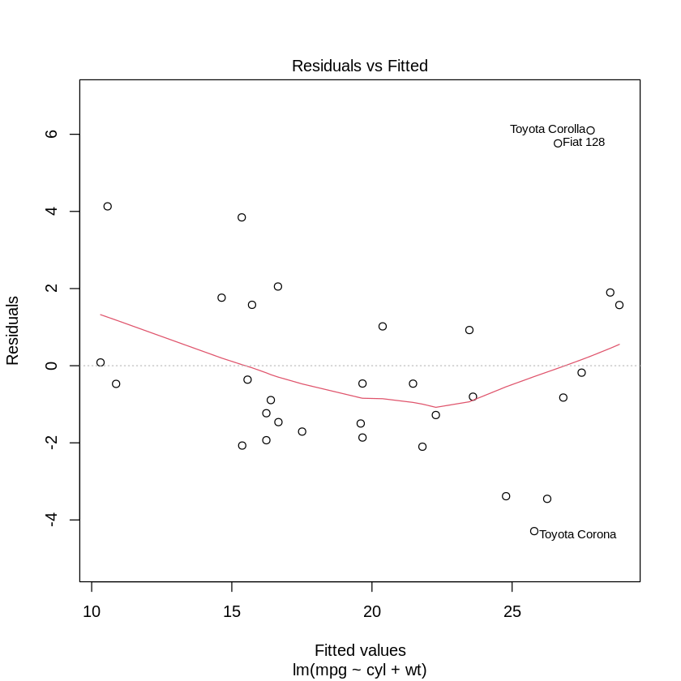

```r
plot(model, which = 1)
```

### 3. After making the model, the residuals seem normally distributed.

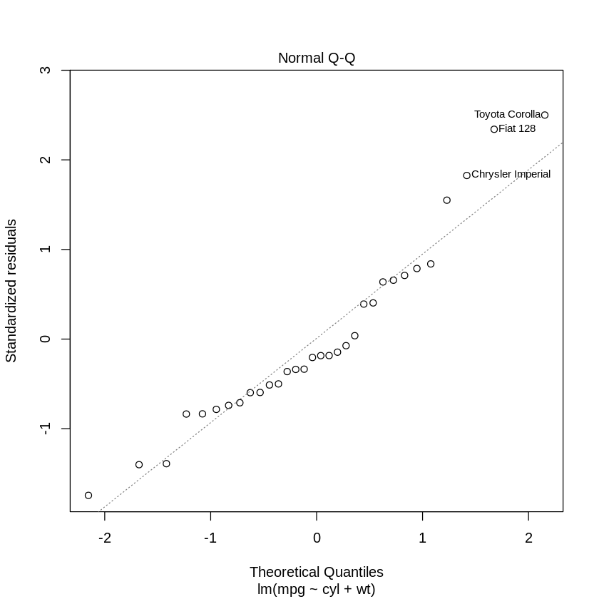

```r
plot(model, which = 2)
```

### 4. After making the model, the residuals seem homoscedastic.

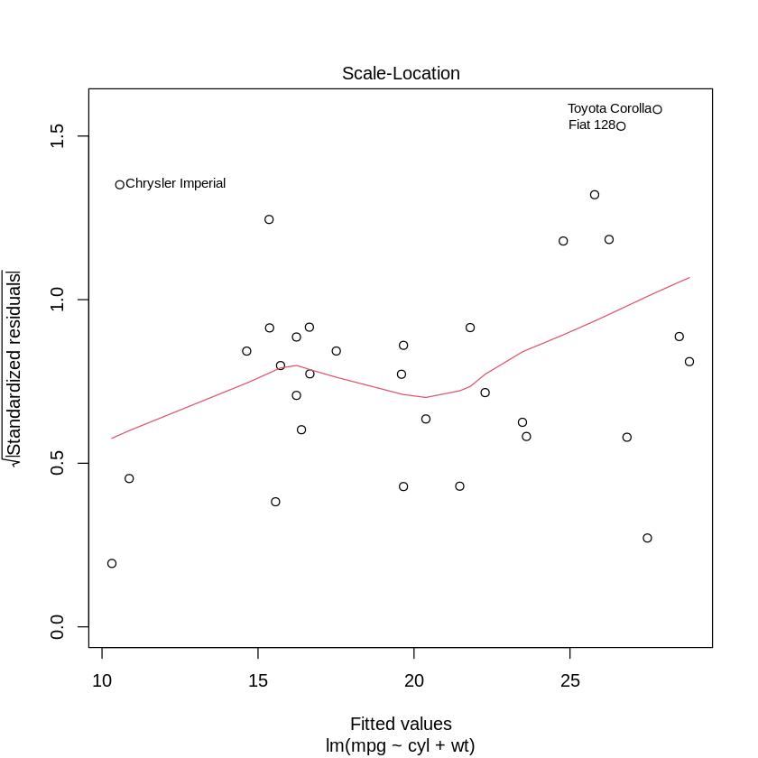

```r
plot(model, which = 3) # assumption of equal variance
```

Content last modified on 24 October 2021.

See a problem? [Tell us](https://github.com/nathancarter/how2data/issues/new/choose) or edit the source.

Contributed by Krtin Juneja (KJUNEJA@falcon.bentley.edu)